# Notebook

**Lineare Regression mit Scikit-Learn**

Dr. Matthias Hölzl

## Beispiel: Lineare Regression mit Scikit-Learn

Wir verwenden das gleiche Beispiel wie vorher:

```python
data_x = [0.5, 1.4, 2.1, 3.5, 4.2, 5.1, 6.3, 7.6, 8.2, 9.0]
data_y = [2.1, 3.5, 5.8, 7.1, 9.3, 11.5, 13.2, 16.0, 17.1, 19.2]
```

## Train-Test Split

### Warum brauchen wir einen Train-Test Split?

- Nach dem Training muss das Modell bewertet werden
- **Die Bewertung muss auf anderen Daten basieren als das Training**
- Andernfalls könnte das Modell die Trainingsdaten "auswendig lernen" (Overfitting)
- Uns interessiert, wie gut das Modell auf **neuen, ungesehenen** Daten funktioniert

## Warum die Daten randomisieren?

- Daten sind oft in einer bestimmten Reihenfolge gesammelt
  - Zeitliche Reihenfolge
  - Sortiert nach bestimmten Eigenschaften
  - Gruppiert nach Kategorien
- Wenn wir die Daten nicht randomisieren, könnten Train- und Testdaten systematisch unterschiedlich sein
- Beispiel: Erste 80% = Sommer, letzte 20% = Winter
- Randomisierung stellt sicher, dass beide Datensätze repräsentativ sind

## Wie viel Prozent für Training und Test?

**Typische Aufteilungen:**

- 80/20 (80% Training, 20% Test): Standard für mittelgroße Datensätze
- 70/30: Wenn mehr Testdaten gewünscht sind
- 90/10: Wenn wenig Daten vorhanden sind

**Faktoren bei der Entscheidung:**

- Größe des Datensatzes: Je weniger Daten, desto mehr für Training
- Komplexität des Modells: Komplexe Modelle brauchen mehr Trainingsdaten
- Variabilität der Daten: Hohe Variabilität erfordert mehr Testdaten

## Train-Test Split mit `train_test_split()`

Scikit-Learn bietet die Funktion `train_test_split()` an:

- Teilt die Daten automatisch auf
- Randomisiert die Daten standardmäßig
- Kann mit `random_state` für reproduzierbare Ergebnisse fixiert werden
- Parameter `test_size`: Anteil der Testdaten (0.0 bis 1.0)

```python
from sklearn.model_selection import train_test_split
```

## Vorbereitung der Daten

- `train_test_split()` erwartet X als 2D-Array (Liste von Listen)
- Jede Zeile ist ein Datenpunkt, jede Spalte ein Feature

```python
# Convert to 2D format (required by scikit-learn)
X = [[x] for x in data_x]
y = data_y
```

```python
X[:5]
```

```
[[0.5], [1.4], [2.1], [3.5], [4.2]]
```

## Durchführung des Train-Test Split

```python
X_train, X_test, y_train, y_test = train_test_split(
    X, y, test_size=0.4, random_state=42
)
```

## Was bedeutet `random_state=42`?

- Die Randomisierung ist eigentlich pseudozufällig
- `random_state` setzt den "Seed" für den Zufallsgenerator
- Mit dem gleichen `random_state` bekommen wir immer die gleiche Aufteilung
- Wichtig für:
  - Reproduzierbarkeit von Ergebnissen
  - Debugging
  - Vergleich verschiedener Modelle

```python
print(f"Total samples: {len(X)}")
print(f"Training samples: {len(X_train)}")
print(f"Test samples: {len(X_test)}")
print(f"Training percentage: {len(X_train) / len(X) * 100:.1f}%")
```

```
Total samples: 10
Training samples: 6
Test samples: 4
Training percentage: 60.0%
```

```python
print("Training data:")
print("X_train:", X_train)
print("y_train:", y_train)
```

```
Training data:
X_train: [[7.6], [2.1], [9.0], [4.2], [3.5], [6.3]]
y_train: [16.0, 5.8, 19.2, 9.3, 7.1, 13.2]
```

```python
print("Test data:")
print("X_test:", X_test)
print("y_test:", y_test)
```

```
Test data:
X_test: [[8.2], [1.4], [5.1], [0.5]]
y_test: [17.1, 3.5, 11.5, 2.1]
```

## Training des Modells mit Scikit-Learn

```python
from sklearn.linear_model import LinearRegression
```

```python
model = LinearRegression()
```

## Vor dem Training

Das Modell ist noch nicht trainiert:

```python
try:
    print(f"Coefficient: {model.coef_}")
    print(f"Intercept: {model.intercept_}")
except AttributeError as e:
    print(f"Error: {e}")
    print("Model is not fitted yet.")
```

```
Error: 'LinearRegression' object has no attribute 'coef_'
Model is not fitted yet.
```

## Training mit `fit()`

```python
model.fit(X_train, y_train)
```

```
LinearRegression()
```

## Nach dem Training

Jetzt sind die Parameter gesetzt:

```python
print(f"Coefficient: {model.coef_[0]:.4f}")
print(f"Intercept: {model.intercept_:.4f}")
```

```
Coefficient: 1.9945
Intercept: 0.8967
```

## Interpretation

- Das Modell hat die Gleichung: y = 2x + 0.9 (ungefähr)
- Für jede Erhöhung von x um 1 steigt y um etwa 2
- Der y-Achsenabschnitt ist etwa 0.9

## Evaluation mit Scikit-Learn

Scikit-Learn bietet viele Metriken zur Modellbewertung:

### Für Regression:

- **Mean Absolute Error (MAE)**: Durchschnittlicher absoluter Fehler
- **Mean Squared Error (MSE)**: Durchschnittlicher quadratischer Fehler
- **Root Mean Squared Error (RMSE)**: Wurzel des MSE
- **R² Score**: Bestimmtheitsmaß (0 bis 1, höher ist besser)

## Mean Absolute Error (MAE)

- Durchschnitt der absoluten Differenzen zwischen Vorhersage und tatsächlichem Wert
- **Einheit**: Gleiche Einheit wie die Zielvariable
- **Interpretation**: Durchschnittliche Abweichung der Vorhersagen
- **Vorteil**: Einfach zu interpretieren, nicht anfällig für Ausreißer
- **Formel**: $\text{MAE} = \frac{1}{n}\sum_{i=1}^{n}|y_i - \hat{y}_i|$

## Mean Squared Error (MSE)

- Durchschnitt der quadrierten Differenzen
- **Einheit**: Quadrat der Einheit der Zielvariable
- **Interpretation**: Bestraft große Fehler stärker
- **Vorteil**: Mathematisch besser zu handhaben (differenzierbar)
- **Nachteil**: Schwerer zu interpretieren durch Quadrierung
- **Formel**: $\text{MSE} = \frac{1}{n}\sum_{i=1}^{n}(y_i - \hat{y}_i)^2$

## Root Mean Squared Error (RMSE)

- Wurzel des MSE
- **Einheit**: Gleiche Einheit wie die Zielvariable
- **Interpretation**: Ähnlich wie MAE, aber bestraft große Fehler stärker
- **Vorteil**: Kombiniert Vorteile von MAE (Einheit) und MSE (Gewichtung)
- **Formel**: $\text{RMSE} = \sqrt{\text{MSE}} = \sqrt{\frac{1}{n}\sum_{i=1}^{n}(y_i - \hat{y}_i)^2}$

## R² Score (Bestimmtheitsmaß)

- Misst, wie gut das Modell die Varianz in den Daten erklärt
- **Bereich**: -∞ bis 1 (normalerweise 0 bis 1)
  - 1: Perfekte Vorhersage
  - 0: Modell ist nicht besser als der Durchschnitt
  - < 0: Modell ist schlechter als der Durchschnitt
- **Vorteil**: Unabhängig von der Einheit, leicht zu interpretieren
- **Formel**: $R^2 = 1 - \frac{\sum_{i=1}^{n}(y_i - \hat{y}_i)^2}{\sum_{i=1}^{n}(y_i - \bar{y})^2}$

## Vorhersagen machen

```python
train_predictions = model.predict(X_train)
test_predictions = model.predict(X_test)
```

```python
print("Training predictions:", train_predictions[:5])
print("Actual training values:", y_train[:5])
```

```
Training predictions: [16.05483809  5.08509724 18.84713576  9.27354375  7.87739491]
Actual training values: [16.0, 5.8, 19.2, 9.3, 7.1]
```

## Evaluation auf Trainingsdaten

```python
from sklearn.metrics import (
    mean_absolute_error,
    mean_squared_error,
    r2_score,
    root_mean_squared_error,
)
```

```python
train_mae = mean_absolute_error(y_train, train_predictions)
train_mse = mean_squared_error(y_train, train_predictions)
train_rmse = root_mean_squared_error(y_train, train_predictions)
train_r2 = r2_score(y_train, train_predictions)
```

```python
print(f"Training Metrics:")
print(f"  MAE:  {train_mae:.4f}")
print(f"  MSE:  {train_mse:.4f}")
print(f"  RMSE: {train_rmse:.4f}")
print(f"  R²:   {train_r2:.4f}")
```

```
Training Metrics:
  MAE:  0.3647
  MSE:  0.2187
  RMSE: 0.4677
  R²:   0.9905
```

## Evaluation auf Testdaten

**Wichtig**: Die Performance auf den Testdaten ist die aussagekräftigere Metrik!

```python
test_mae = mean_absolute_error(y_test, test_predictions)
test_mse = mean_squared_error(y_test, test_predictions)
test_rmse = root_mean_squared_error(y_test, test_predictions)
test_r2 = r2_score(y_test, test_predictions)
```

```python
print(f"Test Metrics:")
print(f"  MAE:  {test_mae:.4f}")
print(f"  MSE:  {test_mse:.4f}")
print(f"  RMSE: {test_rmse:.4f}")
print(f"  R²:   {test_r2:.4f}")
```

```
Test Metrics:
  MAE:  0.2445
  MSE:  0.0718
  RMSE: 0.2680
  R²:   0.9981
```

## Vergleich: Training vs. Test

Ein gutes Modell sollte ähnliche Performance auf beiden Datensätzen zeigen:

```python
print("Comparison:")
print(f"{'Metric':<10} {'Training':<12} {'Test':<12} {'Difference':<12}")
print("-" * 50)
print(
    f"{'MAE':<10} {train_mae:<12.4f} {test_mae:<12.4f} {abs(train_mae - test_mae):<12.4f}"
)
print(
    f"{'MSE':<10} {train_mse:<12.4f} {test_mse:<12.4f} {abs(train_mse - test_mse):<12.4f}"
)
print(
    f"{'RMSE':<10} {train_rmse:<12.4f} {test_rmse:<12.4f} {abs(train_rmse - test_rmse):<12.4f}"
)
print(f"{'R²':<10} {train_r2:<12.4f} {test_r2:<12.4f} {abs(train_r2 - test_r2):<12.4f}")
```

```
Comparison:
Metric     Training     Test         Difference
--------------------------------------------------
MAE        0.3647       0.2445       0.1202
MSE        0.2187       0.0718       0.1469
RMSE       0.4677       0.2680       0.1997
R²         0.9905       0.9981       0.0075
```

## Interpretation der Ergebnisse

- **R² nahe 1**: Das Modell erklärt die Daten sehr gut
- **Kleine MAE/RMSE**: Die Vorhersagen sind im Durchschnitt nah an den wahren Werten
- **Training ≈ Test**: Kein Overfitting, das Modell generalisiert gut
- **Training ≫ Test**: Mögliches Overfitting, Modell ist zu komplex

## Visualisierung der Ergebnisse

```python
X_pred = [x[0] for x in X_train + X_test]
y_pred = model.predict(X_train + X_test)
```

```python
from matplotlib import pyplot as plt
```

```python
def plot_data_and_model():
    plt.figure(figsize=(10, 6))
    plt.scatter(X_train, y_train, alpha=0.6, label="Training data")
    plt.scatter(X_test, y_test, alpha=0.6, label="Test data")
    plt.plot(X_pred, y_pred, "r-", label="Model predictions", linewidth=2)
    plt.xlabel("X")
    plt.ylabel("Y")
    plt.legend()
    plt.title("Linear Regression: Model Fit")
    plt.show()
```

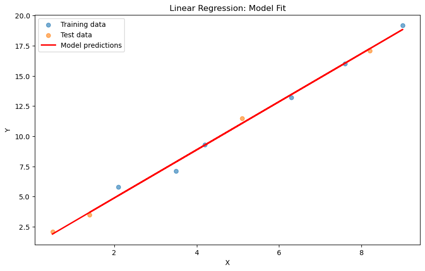

```python
plot_data_and_model()
```

## Evaluierung mit `.score()`

- Die Methode `.score()` bietet eine schnelle Möglichkeit, die Leistung des Modells zu bewerten.
- Hier gibt sie das Bestimmtheitsmaß R² der Vorhersage zurück.

```python
r2_train = model.score(X_train, y_train)
```

```python
r2_train
```

```
0.9905382040690185
```

```python
r2_test = model.score(X_test, y_test)
```

```python
r2_test
```

```
0.9980709496630498
```

## Residuen-Plot

- Zeigt die Fehler (Residuen) für jede Vorhersage
- Ideale Residuen sind zufällig um 0 verteilt
- Muster in den Residuen deuten auf Probleme hin

```python
train_residuals = [y - pred for y, pred in zip(y_train, train_predictions)]
test_residuals = [y - pred for y, pred in zip(y_test, test_predictions)]
```

```python
def plot_residuals():
    plt.figure(figsize=(10, 6))
    plt.scatter(train_predictions, train_residuals, alpha=0.6, label="Training")
    plt.scatter(test_predictions, test_residuals, alpha=0.6, label="Test")
    plt.axhline(y=0, color="r", linestyle="--", linewidth=2)
    plt.xlabel("Predicted values")
    plt.ylabel("Residuals")
    plt.legend()
    plt.title("Residual Plot")
    plt.show()
```

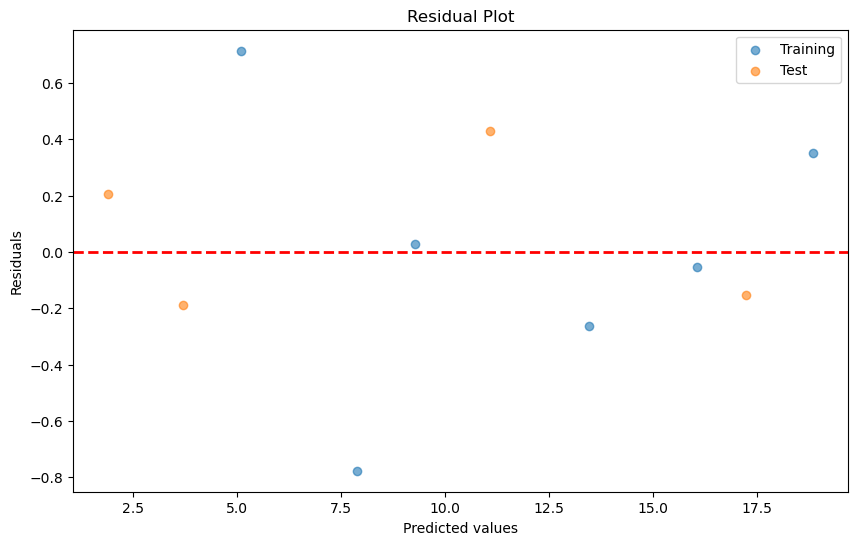

```python
plot_residuals()
```

## Weitere nützliche Scikit-Learn Tools

### Cross-Validation

- Teilt Daten in mehrere Folds auf
- Trainiert und testet Modell mehrfach
- Robustere Schätzung der Modell-Performance

```
from sklearn.model_selection import cross_val_score
scores = cross_val_score(model, X, y, cv=5)
```

### Grid Search

- Systematische Suche nach besten Hyperparametern
- Testet verschiedene Kombinationen von Parametern

```
from sklearn.model_selection import GridSearchCV
param_grid = {'fit_intercept': [True, False]}
grid_search = GridSearchCV(LinearRegression(), param_grid, cv=5)
grid_search.fit(X, y)
```

### Pipelines

- Verketten mehrere Verarbeitungsschritte
- Preprocessing + Training in einem Schritt

```
from sklearn.pipeline import Pipeline
from sklearn.preprocessing import StandardScaler

pipeline = Pipeline([
    ('scaler', StandardScaler()),
    ('model', LinearRegression())
])
pipeline.fit(X_train, y_train)
```

## Zusammenfassung

- **Scikit-Learn** ist eine mächtige und einfach zu benutzende ML-Bibliothek
- **Train-Test Split** ist essentiell zur Bewertung von Modellen
  - Randomisierung verhindert systematische Verzerrungen
  - Typische Aufteilung: 80/20 oder 70/30
- **Evaluation** sollte immer auf den Testdaten erfolgen
  - MAE, MSE, RMSE für absolute Fehler
  - R² für relative Modellgüte
- Scikit-Learn bietet viele weitere Tools (Cross-Validation, Grid Search, Pipelines)

## Workshop: Pizza-Lieferzeit mit Scikit-Learn

In diesem Workshop werden wir nochmal ein Machine Learning Modell trainieren, um die Lieferzeit einer Pizza basierend auf der Entfernung vom Restaurant vorherzusagen. Dabei werden wir die Funktionalität von Scikit-Learn nutzen.

**Ziel**: Anwendung aller gelernten Konzepte:

- Train-Test Split mit `train_test_split()`
- Training mit `LinearRegression`
- Evaluation mit MAE, MSE, RMSE und R²
- Visualisierung der Ergebnisse

Die Daten sind bereits vorbereitet:

- `pizza_distance`: Entfernung vom Restaurant in km
- `pizza_time`: Lieferzeit in Minuten

```python
pizza_distance = [
    1.0,
    1.5,
    2.0,
    2.5,
    3.0,
    3.5,
    4.0,
    4.5,
    5.0,
    5.5,
    6.0,
    6.5,
    7.0,
    7.5,
    8.0,
]
```

```python
pizza_time = [15, 18, 20, 23, 25, 28, 30, 33, 35, 38, 40, 43, 45, 48, 50]
```

```python
print(f"Total data points: {len(pizza_distance)}")
```

```
Total data points: 15
```

### Aufgabe 1: Daten vorbereiten

Bereiten Sie die Daten für Scikit-Learn vor:

- Konvertieren Sie `pizza_distance` in eine 2D-Liste (Liste von Listen)
- Speichern Sie das Ergebnis in `X`
- Speichern Sie `pizza_time` in `y`

```python
X = [[d] for d in pizza_distance]
y = pizza_time
```

```python
print("First 3 samples:")
print(f"X: {X[:3]}")
print(f"y: {y[:3]}")
```

```
First 3 samples:
X: [[1.0], [1.5], [2.0]]
y: [15, 18, 20]
```

### Aufgabe 2: Train-Test Split

Teilen Sie die Daten mit `train_test_split()` auf:

- Verwenden Sie ca. 60% der Daten für das Training (40% für Test)
- Setzen Sie `random_state=42` für Reproduzierbarkeit
- Speichern Sie die Ergebnisse in `X_train`, `X_test`, `y_train`, `y_test`

```python
from sklearn.model_selection import train_test_split

# Your code here...
```

```python
X_train, X_test, y_train, y_test = train_test_split(
    X, y, test_size=0.4, random_state=42
)
```

```python
print(f"Training samples: {len(X_train)}")
print(f"Test samples: {len(X_test)}")
print(f"Training percentage: {len(X_train) / len(X) * 100:.1f}%")
```

```
Training samples: 9
Test samples: 6
Training percentage: 60.0%
```

### Aufgabe 3: Modell trainieren

Trainieren Sie ein lineares Regressionsmodell:

- Erstellen Sie ein `LinearRegression` Modell
- Trainieren Sie es mit den Trainingsdaten
- Geben Sie die gelernten Parameter (Koeffizient und Intercept) aus

```python
from sklearn.linear_model import LinearRegression
```

```python
model = LinearRegression()
model.fit(X_train, y_train)
```

```
LinearRegression()
```

```python
print(f"Coefficient (slope): {model.coef_[0]:.4f} min/km")
print(f"Intercept: {model.intercept_:.4f} min")
print(f"\nModel equation: y = {model.coef_[0]:.4f}x + {model.intercept_:.4f}")
```

```
Coefficient (slope): 4.9485 min/km
Intercept: 10.3871 min

Model equation: y = 4.9485x + 10.3871
```

### Aufgabe 4: Vorhersagen machen

Erstellen Sie Vorhersagen für Trainings- und Testdaten:

- Verwenden Sie `model.predict()` für beide Datensätze
- Speichern Sie die Ergebnisse in `train_predictions` und `test_predictions`

```python
train_predictions = model.predict(X_train)
test_predictions = model.predict(X_test)
```

```python
print("Sample predictions vs actual values:")
for i in range(min(3, len(X_test))):
    print(
        f"Distance: {X_test[i][0]:.1f} km → "
        f"Predicted: {test_predictions[i]:.1f} min, "
        f"Actual: {y_test[i]} min"
    )
```

```
Sample predictions vs actual values:
Distance: 5.5 km → Predicted: 37.6 min, Actual: 38 min
Distance: 6.5 km → Predicted: 42.6 min, Actual: 43 min
Distance: 1.0 km → Predicted: 15.3 min, Actual: 15 min
```

### Aufgabe 5: Modell evaluieren

Berechnen Sie die folgenden Metriken für Trainings- und Testdaten:

- MAE (Mean Absolute Error)
- MSE (Mean Squared Error)
- RMSE (Root Mean Squared Error)
- R² Score

Verwenden Sie die entsprechenden Funktionen aus `sklearn.metrics`.

```python
from sklearn.metrics import (
    mean_absolute_error,
    mean_squared_error,
    root_mean_squared_error,
    r2_score,
)

# Your code here...
```

```python
# Training metrics
train_mae = mean_absolute_error(y_train, train_predictions)
train_mse = mean_squared_error(y_train, train_predictions)
train_rmse = root_mean_squared_error(y_train, train_predictions)
train_r2 = r2_score(y_train, train_predictions)

# Test metrics
test_mae = mean_absolute_error(y_test, test_predictions)
test_mse = mean_squared_error(y_test, test_predictions)
test_rmse = root_mean_squared_error(y_test, test_predictions)
test_r2 = r2_score(y_test, test_predictions)
```

```python
print("Training Metrics:")
print(f"  MAE:  {train_mae:.4f} min")
print(f"  MSE:  {train_mse:.4f} min²")
print(f"  RMSE: {train_rmse:.4f} min")
print(f"  R²:   {train_r2:.4f}")
```

```
Training Metrics:
  MAE:  0.1782 min
  MSE:  0.0432 min²
  RMSE: 0.2077 min
  R²:   0.9996
```

```python
print("\nTest Metrics:")
print(f"  MAE:  {test_mae:.4f} min")
print(f"  MSE:  {test_mse:.4f} min²")
print(f"  RMSE: {test_rmse:.4f} min")
print(f"  R²:   {test_r2:.4f}")
```

```
Test Metrics:
  MAE:  0.3503 min
  MSE:  0.1370 min²
  RMSE: 0.3702 min
  R²:   0.9988
```

### Aufgabe 6: Metriken vergleichen

Erstellen Sie eine übersichtliche Vergleichstabelle der Metriken für Trainings- und Testdaten.

**Analysieren Sie die Ergebnisse:**

- Sind die Metriken ähnlich für Training und Test?
- Was sagt der R² Score über die Modellqualität aus?
- Wie groß ist die durchschnittliche Abweichung (MAE)?

```python
print("Comparison: Training vs. Test")
print("=" * 60)
print(f"{'Metric':<10} {'Training':<12} {'Test':<12} {'Difference':<12}")
print("-" * 60)
print(
    f"{'MAE':<10} {train_mae:<12.4f} {test_mae:<12.4f} {abs(train_mae - test_mae):<12.4f}"
)
print(
    f"{'MSE':<10} {train_mse:<12.4f} {test_mse:<12.4f} {abs(train_mse - test_mse):<12.4f}"
)
print(
    f"{'RMSE':<10} {train_rmse:<12.4f} {test_rmse:<12.4f} {abs(train_rmse - test_rmse):<12.4f}"
)
print(f"{'R²':<10} {train_r2:<12.4f} {test_r2:<12.4f} {abs(train_r2 - test_r2):<12.4f}")
```

```
Comparison: Training vs. Test
============================================================
Metric     Training     Test         Difference
------------------------------------------------------------
MAE        0.1782       0.3503       0.1721
MSE        0.0432       0.1370       0.0939
RMSE       0.2077       0.3702       0.1625
R²         0.9996       0.9988       0.0008
```

```python
print("\nInterpretation:")
print(f"- R² = {test_r2:.4f}: Das Modell erklärt {test_r2*100:.2f}% der Varianz")
print(
    f"- MAE = {test_mae:.4f}: Durchschnittliche Abweichung von {test_mae:.2f} Minuten"
)
print(f"- Training/Test sehr ähnlich → Gute Generalisierung, kein Overfitting")
```

```
Interpretation:
- R² = 0.9988: Das Modell erklärt 99.88% der Varianz
- MAE = 0.3503: Durchschnittliche Abweichung von 0.35 Minuten
- Training/Test sehr ähnlich → Gute Generalisierung, kein Overfitting
```

### Aufgabe 7: Ergebnisse visualisieren

Erstellen Sie einen Plot, der zeigt:

- Die Trainingsdaten als Scatter-Plot (blau)
- Die Testdaten als Scatter-Plot (orange)
- Die Modellvorhersagen als rote Linie

Beschriften Sie die Achsen und fügen Sie eine Legende hinzu.

```python
import matplotlib.pyplot as plt
```

```python
# Create a range of distances for the prediction line
distance_range = [[x * 0.1] for x in range(0, 90)]
time_predictions = model.predict(distance_range)
```

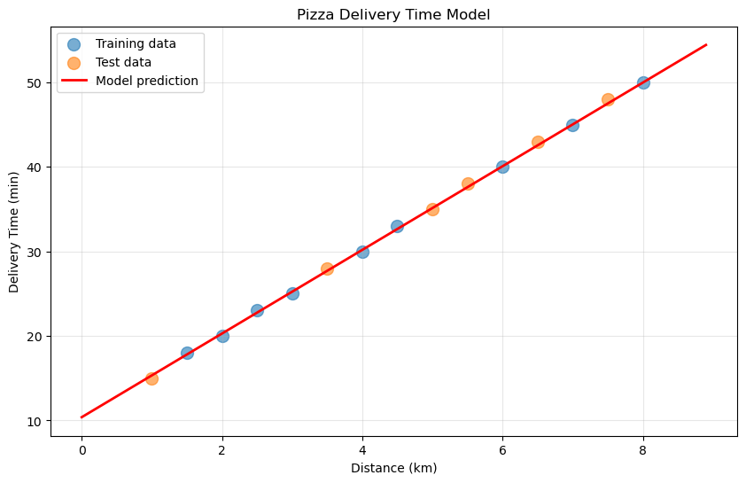

```python
plt.figure(figsize=(10, 6))
plt.scatter(X_train, y_train, alpha=0.6, label="Training data", s=100)
plt.scatter(X_test, y_test, alpha=0.6, label="Test data", s=100)
plt.plot(
    [d[0] for d in distance_range],
    time_predictions,
    "r-",
    label="Model prediction",
    linewidth=2,
)
plt.xlabel("Distance (km)")
plt.ylabel("Delivery Time (min)")
plt.title("Pizza Delivery Time Model")
plt.legend()
plt.grid(True, alpha=0.3)
plt.show()
```

### Aufgabe 8: Residuen-Plot

Erstellen Sie einen Residuen-Plot:

- X-Achse: Vorhergesagte Werte
- Y-Achse: Residuen (Fehler = tatsächlicher Wert - vorhergesagter Wert)
- Plotten Sie Trainings- und Testdaten
- Fügen Sie eine horizontale Linie bei y=0 hinzu

**Analysieren Sie:** Sind die Residuen zufällig um 0 verteilt?

```python
# Your code here...
```

```python
train_residuals = [y - pred for y, pred in zip(y_train, train_predictions)]
test_residuals = [y - pred for y, pred in zip(y_test, test_predictions)]
```

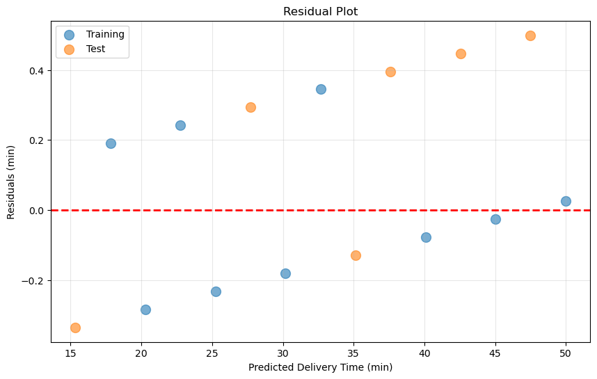

```python
plt.figure(figsize=(10, 6))
plt.scatter(train_predictions, train_residuals, alpha=0.6, label="Training", s=100)
plt.scatter(test_predictions, test_residuals, alpha=0.6, label="Test", s=100)
plt.axhline(y=0, color="r", linestyle="--", linewidth=2)
plt.xlabel("Predicted Delivery Time (min)")
plt.ylabel("Residuals (min)")
plt.title("Residual Plot")
plt.legend()
plt.grid(True, alpha=0.3)
plt.show()
```

### Aufgabe 9: Neue Vorhersagen

Verwenden Sie das trainierte Modell, um die Lieferzeit für folgende Entfernungen vorherzusagen:

- 2.8 km
- 5.2 km
- 9.0 km
- 10.5 km

```python
# Your code here...
```

```python
new_distances = [[2.8], [5.2], [9.0], [10.5]]
new_predictions = model.predict(new_distances)
```

```python
print("Predictions for new distances:")
print("-" * 50)
for distance, time in zip(new_distances, new_predictions):
    print(
        f"Distance: {distance[0]:5.1f} km → "
        f"Predicted delivery time: {time:5.1f} min"
    )
```

```
Predictions for new distances:
--------------------------------------------------
Distance:   2.8 km → Predicted delivery time:  24.2 min
Distance:   5.2 km → Predicted delivery time:  36.1 min
Distance:   9.0 km → Predicted delivery time:  54.9 min
Distance:  10.5 km → Predicted delivery time:  62.3 min
```

### Aufgabe 10: Modellqualität einschätzen

**Diskussionsfragen:**

1. Ist das Modell gut für die Vorhersage geeignet? (Betrachten Sie R²)
2. Wie groß ist der durchschnittliche Fehler in Minuten? (Betrachten Sie MAE)
3. Sind die Residuen zufällig verteilt oder zeigen sie ein Muster?
4. Würden Sie dem Modell für die 10.5 km Vorhersage vertrauen? Warum (nicht)?
5. Was bedeutet es, dass Training und Test Metriken sehr ähnlich sind?

**Mögliche Antworten:**

1. **Modellqualität**: R² nahe 1 (z.B. > 0.95) zeigt, dass das Modell die Daten sehr gut erklärt
2. **Durchschnittlicher Fehler**: MAE gibt an, wie viele Minuten die Vorhersage im Durchschnitt abweicht (z.B. ±2 Minuten)
3. **Residuen**: Idealerweise zufällig verteilt ohne erkennbares Muster. Hier haben wir aber einen deutlich erkennbaren systematischen Fehler
4. **10.5 km Vorhersage**: Vorsicht bei Extrapolation! Das Modell wurde nur bis 8 km trainiert
5. **Training ≈ Test**: Das Modell generalisiert gut, kein Overfitting